# Unique Features of R for Programmers

2024-11-19

## Introduction

- **R** offers powerful features that set it apart in the programming world.
- Let’s explore some unique aspects that make R interesting for programmers.

## Vectorized Operations

- Perform operations on entire vectors without explicit loops.
- Leads to concise and efficient code.

```r
# Vectorized addition
a <- 1:5
b <- 6:10
result <- a + b
print(result)  # Outputs: 7 9 11 13 15
```

```
## [1]  7  9 11 13 15
```

## Functional Programming Paradigms

- Functions are first-class citizens.
- Supports higher-order functions, closures, and function factories.

```r
# Function returning another function
power_factory <- function(n) {
  function(x) x ^ n
}
square <- power_factory(2)
cube <- power_factory(3)
square(4)  # Outputs: 16
```

```
## [1] 16
```

```r
cube(2)    # Outputs: 8
```

```
## [1] 8
```

## Lazy Evaluation

- Arguments are evaluated only when needed.
- Enables flexible and efficient function definitions.

```r
# Lazy evaluation example
lazy_function <- function(x, y) {
  if (x > 0) x else y
}
result <- lazy_function(5, {print("y is evaluated"); 0})
print(result)  # Outputs: 5
```

```
## [1] 5
```

```r
# "y is evaluated" is not printed
```

## Metaprogramming Capabilities

- Modify and generate code at runtime.
- Use expressions and environments to manipulate code objects.

```r
# Creating a function from an expression
expr <- expression(function(x) x + 1)
increment <- eval(expr)
increment(5)  # Outputs: 6
```

```
## [1] 6
```

## Non-Standard Evaluation (NSE)

- Functions can capture expressions instead of values.
- Simplifies syntax for data manipulation and modeling.

Let’s first import dplyer:

```r
library(dplyr)
```

Then we can peform data manipulation simply using “verbs”:

```r
# Using NSE in dplyr
result <- mtcars %>%
  select(mpg, cyl) %>%
  filter(cyl == 6)
print(result)
```

```
##                 mpg cyl
## Mazda RX4      21.0   6
## Mazda RX4 Wag  21.0   6
## Hornet 4 Drive 21.4   6
## Valiant        18.1   6
## Merc 280       19.2   6
## Merc 280C      17.8   6
## Ferrari Dino   19.7   6
```

## Advanced Graphics with ggplot2

- Create complex and customizable visualizations.
- Based on the **Grammar of Graphics**.

```r
library(ggplot2)

# Create the plot and store it in a variable
p <- ggplot(mtcars, aes(x = wt, y = mpg, color = factor(gear))) +
     geom_point(size = 3) +
     labs(
       title = "Fuel Efficiency by Car Weight",
       x = "Weight (1000 lbs)",
       y = "Miles per Gallon",
       color = "Gears"
     ) +
     theme_minimal()
```

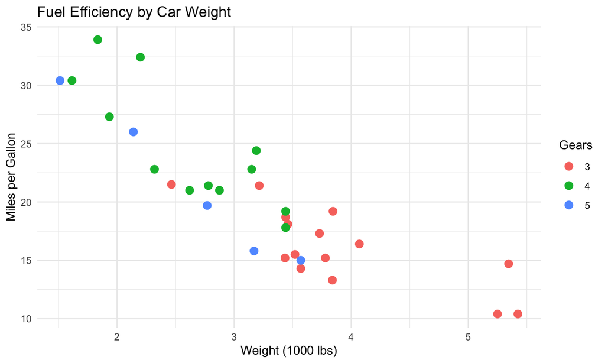

```r
# Display the plot
p
```

## Interfacing with Other Languages

- Integrate C/C++ code for performance-critical sections using **Rcpp**.
- Interface with Python via **reticulate**.

```r
library(Rcpp)
cppFunction('
int fibonacci(int n) {
  if (n <= 1) return n;
  else return(fibonacci(n - 1) + fibonacci(n - 2));
}')
fibonacci(10)  # Outputs: 55
```

```
## [1] 55
```

## Statistical Modeling and Machine Learning

- Extensive support for statistical analyses.
- Machine learning libraries like **caret**, **xgboost**, and **randomForest**.

```r
library(randomForest)
model <- randomForest(Species ~ ., data = iris)
print(model)
```

```
##
## Call:
##  randomForest(formula = Species ~ ., data = iris)
##                Type of random forest: classification
##                      Number of trees: 500
## No. of variables tried at each split: 2
##
##         OOB estimate of  error rate: 4.67%
## Confusion matrix:
##            setosa versicolor virginica class.error
## setosa         50          0         0        0.00
## versicolor      0         47         3        0.06
## virginica       0          4        46        0.08
```

## Parallel Computing

- Utilize multiple cores with packages like **parallel** and **foreach**.
- Simplifies parallelization of code.

```r
library(parallel)
results <- mclapply(1:5, function(x) x^2, mc.cores = 2)
print(results)  # Outputs: List of squared numbers
```

```
## [[1]]
## [1] 1
##
## [[2]]
## [1] 4
##
## [[3]]
## [1] 9
##
## [[4]]
## [1] 16
##
## [[5]]
## [1] 25
```

## Rich Ecosystem and Community

- Over 16,000 packages available on CRAN.
- Active community contributing to diverse domains.

```r
install.packages(c("dplyr", "ggplot2", "Rcpp", "randomForest", "parallel"))
```